# AdaBoost Example

Data Science Dojo

February 2017

**NOTE** - This document is part of Data Science Dojo’s Bootcamp educational services offerings, Copyright (c) 2015-2017.

## Introduction

This R Markdown document provides an example implementation of the AdaBoost algorithm. It is specifically designed to be as intuitive as possible using R code as the learning vehicle. As such, clarity of understanding of both concepts and R code have taken precedence over other concerns (e.g., code efficiency, modularity, compactness, etc.).

From the lecture materials we know the AdaBoost algorithm can be thought of precedurally (i.e., at a higher level of abstraction) as follows:

1. Intialize a vector of weights with each member having a value of $1/N$ where $N$ is the number of observations in the training set.
2. Let $k$ be the number of boosting rounds (i.e., the number of models to train).
3. **for** $i = 1$ to $k$ **do**
4. Train a weight-aware classifier, $C_i$, on the weighted training set.
5. Use $C_i$ to create predictions for all training set observations.
6. Calculated the wieghted error, $\epsilon_i$, for $C_i$.
7. **if** $\epsilon_i$ > 0.5 **then**
8. Reset weights per #1.
9. Go to step #4.
10. **end if**
11. Calculate the importance, $\alpha_i$, for $C_i$.
12. Update the training set observation weights.
13. **end for**
14. Create predictions based on the importance-based combination of learners.

The R code implementation of AdaBoost in this document follows the above procedure and specifically consists of the following.

- Use of `rpart` single-level decision trees (common called “descision stumps”) as the weak learner for each round:
  - `rpart` trees can be passed training weight vectors to effect the training of the learners.
  - `rpart` trees are very easy to understand and can be represented intuitively using visualizations.
- The usage of 3 weak learners (i.e., 3 rounds of the algorithm) trained on the dataset:
  - The value of $k$ in step #2 above is 3.
  - We will leave it as an exercise to the reader to find out if additional rounds increase the accuracy of the boosted enesmble.

## Data Exploration

To illustrate the implementation of the AdaBoost algorithm we will leverage the [Johns Hopkins University Ionosphere database](https://archive.ics.uci.edu/ml/datasets/Ionosphere). This dataset represents a binary classification problem that is the happy path scenario for the AdaBoost algorithm. The following code provides an exploratoin of the data set.

```r
# Load mlbench library and dataset
library(mlbench)
data("Ionosphere")

# Structure of the dataset
str(Ionosphere)
```

```
## 'data.frame':    351 obs. of  35 variables:
##  $ V1   : Factor w/ 2 levels "0","1": 2 2 2 2 2 2 2 1 2 2 ...
##  $ V2   : Factor w/ 1 level "0": 1 1 1 1 1 1 1 1 1 1 ...
##  $ V3   : num  0.995 1 1 1 1 ...
##  $ V4   : num  -0.0589 -0.1883 -0.0336 -0.4516 -0.024 ...
##  $ V5   : num  0.852 0.93 1 1 0.941 ...
##  $ V6   : num  0.02306 -0.36156 0.00485 1 0.06531 ...
##  $ V7   : num  0.834 -0.109 1 0.712 0.921 ...
##  $ V8   : num  -0.377 -0.936 -0.121 -1 -0.233 ...
##  $ V9   : num  1 1 0.89 0 0.772 ...
##  $ V10  : num  0.0376 -0.0455 0.012 0 -0.164 ...
##  $ V11  : num  0.852 0.509 0.731 0 0.528 ...
##  $ V12  : num  -0.1776 -0.6774 0.0535 0 -0.2028 ...
##  $ V13  : num  0.598 0.344 0.854 0 0.564 ...
##  $ V14  : num  -0.44945 -0.69707 0.00827 0 -0.00712 ...
```

[output cut: 21 more lines]

```r
# Example observation
head(Ionosphere, 1)
```

```
##   V1 V2      V3       V4      V5      V6      V7       V8 V9    V10
## 1  1  0 0.99539 -0.05889 0.85243 0.02306 0.83398 -0.37708  1 0.0376
##       V11      V12     V13      V14     V15      V16     V17      V18
## 1 0.85243 -0.17755 0.59755 -0.44945 0.60536 -0.38223 0.84356 -0.38542
##       V19      V20     V21      V22     V23      V24     V25      V26
## 1 0.58212 -0.32192 0.56971 -0.29674 0.36946 -0.47357 0.56811 -0.51171
##       V27      V28     V29     V30     V31      V32     V33    V34 Class
## 1 0.41078 -0.46168 0.21266 -0.3409 0.42267 -0.54487 0.18641 -0.453  good
```

In examining the output above it is worthy to note the following:

1. There are a total of 351 observations.
2. There are a total of 35 variables:
   - 34 *independent variables* (i.e., predictors), named `V1` through `V34`.
   - Variables `V1` and `V2` are factor variables.
   - 1 *dependent variable* (i.e., the label) named `class`.
3. The labels we are trying to predict are `good` and `bad`.

## Data Prep

The following R code preps the `Ionosphere` data for the AdaBoost implementation.

```r
# Leverage the caret package to produce a 70/30 training/test split
library(caret)
set.seed(3243)
indexes <- createDataPartition(Ionosphere$Class, p = 0.7, list = FALSE)

train <- Ionosphere[indexes,]
test <- Ionosphere[-indexes,]

# Randomize training observations
library(dplyr)
train <- sample_n(train, nrow(train))
```

## Background and Setup

This example will leverage single-level decision trees (“decision stumps”) as the AdaBoost weak learners. The AdaBoost algorithm allows for the use of any classification algorithm that can accept weighted training observations. The use of weights with the training data allows the AdaBoost algorithm to identify those observations that are difficult to classify correctly, allowing subsequent weak learners to focus on correctly classifying these difficult examples. The `rpart` package allows for the creation of decision stumps with weighted training observations. The following code provides the required setup.

```r
# Create initial weights
weights <- rep(1 / nrow(train), nrow(train))

# Load and configure rpart for decision stumps
library(rpart)

cntrl <- rpart.control(maxdepth = 1)
```

## Round 1

#### Building the Model

This section implements Round 1 of the AdaBoost algorithm, starting with construction of the first weak learner (descision stump) and graphically displays the learned model.

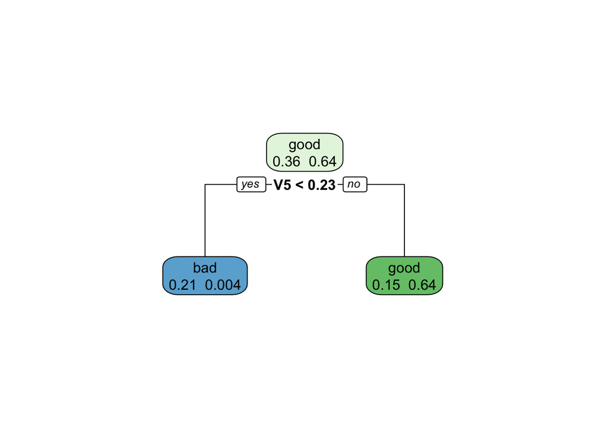

```r
# Train first decision stump.
model.1 <- rpart(Class ~ V1 + V2 + V3 + V4 + V5 + V6 + V7 + V8 + V9 + V10 + V11 + V12 +
                         V13 + V14 + V15 + V16 + V17 + V18 + V19 + V20 + V21 + V22 + V23 +
                         V24 + V25 + V26 + V27 + V28 + V29 + V30 + V31 + V32 + V33 + V34,
                 data = train, weights = weights, control = cntrl)

# Use rpart.plot to visualize tree
library(rpart.plot)

rpart.plot(model.1, extra = 1)
```

The output above illustrates that the Round 1 decision stump splits on the value of `V5` and leverages a critera of values less than 0.23. Here’s how to read the above visualization:

- The first piece of information is the predicted class label (i.e., `bad` or `good`).
- The second piece of information is the relative percentages of all observations in each node by label.

For example, looking at the node in the lower right:

1. Observations that have `V5` values >= 0.23 are assgined a label of `good`.
2. Observations that end up in this node with a label of `bad` represent 15% of all the training observations.
3. Observations that end up in this node with a label of `good` represent 64% of all training observations.

In looking at the visualization, our intuition is that AdaBoost will prioritize looking at observations that are labeled `bad` in the next round as the Round 1 weak learner is missclassifying 15% of the training observations.

#### Calculating the Error

Per the AdaBoost algorithm, the next step is to quantify the error rate for `model.1` using the following formula:

$$\epsilon_i = \frac{1}{N}\sum_{j=1}^{N}w_j\delta\left(C_i(x_j) \neq y_j \right)$$

It is useful to unpack the formula above into the constiuent elements for our implementation in R:

1. $N$ - Denotes the total number of observations in the training set.
2. $j$ - Denotes an observation in the training set.
3. $C_i$ - Denotes the current classifier of the round (i.e., `model.1` in this case.).
4. $C_i(x_j)$ - Denotes the predicition of the current classifier for observation $j$.
5. $y_j$ - Denotes the actual label for observation $j$.
6. $\delta \left(C_i(x_j) \neq y_j \right)$ - Denotes a function that returns 0 when #2 correctly predicts #3 and returns a 1 when #2 incorrectly predicts #3.
7. $w_j$ - Denotes the current weight for observation $j$.
8. $\sum_{j=1}^{N}$ - Denotes iterating through all observations in the training set, adding up $w_j$ where there are incorrect predictions.
9. $\frac{1}{N}$ - Denotes dividing #8 by the number of observations in the training set.

Using the above, the folloing R code calculates the error for Round 1 (i.e., for `model.1`).

```r
# Make predictions - Corresponds to #4 of the equation above.
model.1.preds <- predict(model.1, train, type = "class")

# Get indexes of errors - Corresponds to #6 of the equation above.
indexes <- which(model.1.preds != train$Class)

# Calculate Round 1 error - Corresponds to #7, 8, & 9 of the equation above.
round.1.error <- sum(weights[indexes]) / nrow(train)
round.1.error
```

```
## [1] 0.0006228589
```

#### Calculating the Importance

Next up is calculating the importance of the Round 1 classifier per the following equation:

$$\alpha_i = \frac{1}{2}ln\left(\frac{1 - \epsilon_i}{\epsilon_i} \right)$$

```r
# Calculate the importance (alpha) of the Round 1 weak learner (model.1)
round.1.alpha <- 0.5 * log((1 - round.1.error) / round.1.error)
round.1.alpha
```

```
## [1] 3.690284
```

#### Updating the Weights

Lastly, we need to update the training observation weights based on the following equation:

$$w_j^{(i+1)} = \frac{w_j^{(i)}}{Z_i}\begin{cases}e^{-a_i}, & if & C_i(x_j) = y_j\\e^{a_i} & if & C_i(x_j) \neq y_j\end{cases}$$

```r
# Update weights for correct predictions, making them smaller
weights[-indexes] <- exp(-round.1.alpha)
exp(-round.1.alpha)
```

```
## [1] 0.02496492
```

```r
# Update weights for incorrect predictions, making them larger
weights[indexes] <- exp(round.1.alpha)
exp(round.1.alpha)
```

```
## [1] 40.05621
```

```r
# Normalize weights so they add up to one
weights <- weights / sum(weights)
```

## Round 2

This section implements Round 2 of the AdaBoost algorithm, starting with construction of the second weak learner that focuses on the misclassified (and hence boosted) observations from the first round of training.

#### Building the Model

The followng code trains a decision stump with the boosted observation weights and visually displays the resulting tree.

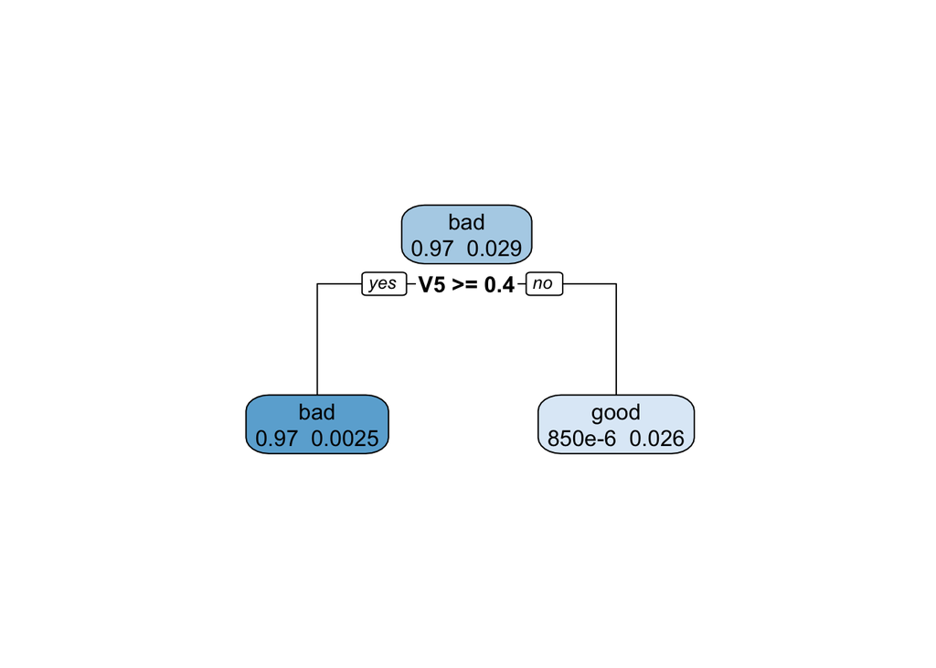

```r
# Train second decision stump.
model.2 <- rpart(Class ~ V1 + V2 + V3 + V4 + V5 + V6 + V7 + V8 + V9 + V10 + V11 + V12 +
                         V13 + V14 + V15 + V16 + V17 + V18 + V19 + V20 + V21 + V22 + V23 +
                         V24 + V25 + V26 + V27 + V28 + V29 + V30 + V31 + V32 + V33 + V34,
                 data = train, weights = weights, control = cntrl)

# Use rpart.plot to visualize tree
rpart.plot(model.2, extra = 1)
```

As we can see from the visualization above, the second weak learner has focused on classifying training observations with a label of `bad`. This aligns with our intuition of how AdaBoost works - the algorithm prioritized building a model to address misclassification errors from the previous round.

#### Calculating the Error

Per the AdaBoost algorithm, the next step is to calculate the Round 2 error.

```r
# Make predictions.
model.2.preds <- predict(model.2, train, type = "class")

# Get indexes of errors.
indexes <- which(model.2.preds != train$Class)

# Calculate Round 2 error.
round.2.error <- sum(weights[indexes]) / nrow(train)
round.2.error
```

```
## [1] 1.336734e-05
```

As the output above illustrated, the Round 2 weak learner - by virtue of focusing on boosted observations from Round 1 has a lower error rate than the Round 1 weak learner.

#### Calculating the Importance

Next up is calculating Round 2 importance.

```r
# Calculate the importance (alpha) of the Round 2 weak learner (model.2)
round.2.alpha <- 0.5 * log((1 - round.2.error) / round.2.error)
round.2.alpha
```

```
## [1] 5.611341
```

As on one would expect, the AdaBoost algorithm assigns more importance to the Round 2 model than it does the Round 1 model because it’s overall prediction error is less (i.e., the Round 2 model is more accurate).

#### Updating the Weights

Lastly, adjusting the observation weights for Round 2.

```r
# Update weights for correct predictions, making them smaller
weights[-indexes] <- exp(-round.2.alpha)
exp(-round.2.alpha)
```

```
## [1] 0.003656162
```

```r
# Update weights for incorrect predictions, making them larger
weights[indexes] <- exp(round.2.alpha)
exp(round.2.alpha)
```

```
## [1] 273.5109
```

```r
# Normalize weights so they add up to one
weights <- weights / sum(weights)
```

## Round 3

This section implements Round 3 of the AdaBoost algorithm, starting with construction of the final weak learner that focuses on the misclassified (and hence boosted) observations from the second round of training. The followng code trains a decision stump with the boosted observation weights and visually displays the resulting tree.

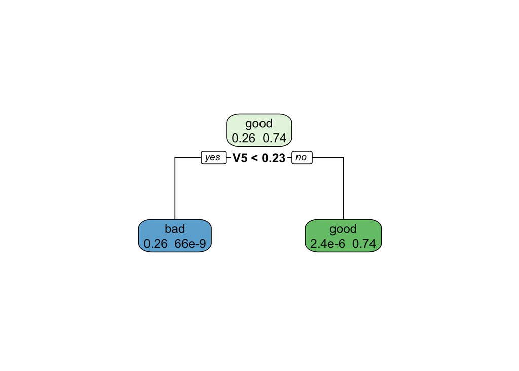

```r
# Train thrid decision stump.
model.3 <- rpart(Class ~ V1 + V2 + V3 + V4 + V5 + V6 + V7 + V8 + V9 + V10 + V11 + V12 +
                         V13 + V14 + V15 + V16 + V17 + V18 + V19 + V20 + V21 + V22 + V23 +
                         V24 + V25 + V26 + V27 + V28 + V29 + V30 + V31 + V32 + V33 + V34,
                 data = train, weights = weights, control = cntrl)

# Use rpart.plot to visualize tree
rpart.plot(model.3, extra = 1)
```

As we can see from the visualization above, the third weak learner has switched focus back to observations labeled `good`. This is intuitive as we know that Round 2 focused on those observations labeled `bad`.

#### Calculating the Error

Per the AdaBoost algorithm, the next step is to calculate the Round 3 error.

```r
# Make predictions.
model.3.preds <- predict(model.3, train, type = "class")

# Get indexes of errors.
indexes <- which(model.3.preds != train$Class)

# Calculate Round 3 error.
round.3.error <- sum(weights[indexes]) / nrow(train)
round.3.error
```

```
## [1] 1.018087e-08
```

As the output above illustrated, the Round 3 weak learner - by virtue of focusing on boosted observations from Round 2 has a lower error rate than the Round 2 weak learner.

#### Calculating the Importance

Next up is calculating Round 3 importance.

```r
# Calculate the importance (alpha) of the Round 2 weak learner (model.3)
round.3.alpha <- 0.5 * log((1 - round.3.error) / round.3.error)
round.3.alpha
```

```
## [1] 9.201378
```

As on one would expect, the AdaBoost algorithm assigns the most importance to the Round 3 model as it has the lowest prediction error (i.e., it is the most accurate model) built so far.

#### Updating the Weights

Lastly, adjusting the observation weights for Round 3.

```r
# Update weights for correct predictions, making them smaller
weights[-indexes] <- exp(-round.3.alpha)
exp(-round.3.alpha)
```

```
## [1] 0.0001009003
```

```r
# Update weights for incorrect predictions, making them larger
weights[indexes] <- exp(round.3.alpha)
exp(round.3.alpha)
```

```
## [1] 9910.775
```

```r
# Normalize weights so they add up to one
weights <- weights / sum(weights)
```

## Making Predictions

When making predictions with AdaBoost there are two primary things to keep in mind:

1. AdaBoost doesn’t use a majority vote scheme for classification like other algorithms (e.g., Random Forests).
2. AdaBoost uses a weighted prediction scheme leveraging label values of -1.0 and 1.0 instead of string labels.

Given the above, the following R code creates predictions on the test set for all weak learners and converts the predictions from `bad` and `good` to -1.0 and 1.0 respectively.

```r
# Make predictions for all models on test set
round.1.preds <- predict(model.1, test, type = "class")
round.2.preds <- predict(model.2, test, type = "class")
round.3.preds <- predict(model.3, test, type = "class")

# Convert predictions
round.1.preds <- ifelse(round.1.preds == "bad", -1.0, 1.0)
round.2.preds <- ifelse(round.2.preds == "bad", -1.0, 1.0)
round.3.preds <- ifelse(round.3.preds == "bad", -1.0, 1.0)
```

Per the AdaBoost algorithm, the following is the mathematical formula for creating predictions for the trained ensemble of weak learners:

$$C^*(x) = \underset{y}{argmax}\sum_{j=1}^{T}\alpha_j\delta(C_j(x) = y)$$

The following R code implements the above equation in terms of our simple ensemble of learners and then leverages threshold logic to convert back into labels of `bad` and `good`.

```r
# Calculate predictions using above mathematical equations
ensemble.preds.raw <- (round.1.alpha * round.1.preds) + (round.2.alpha * round.2.preds) +
                      (round.3.alpha * round.3.preds)

ensemble.preds <- as.factor(ifelse(ensemble.preds.raw < 0.0, "bad", "good"))
```

Lastly, we can use the `confusionMatrix()` function from the `caret` package to examine the accuracy of our AdaBoost ensemble.

```r
# Output statistics for the AdaBoost ensemble
confusionMatrix(ensemble.preds, test$Class)
```

```
## Confusion Matrix and Statistics
##
##           Reference
## Prediction bad good
##       bad   21    3
##       good  16   64
##
##                Accuracy : 0.8173
##                  95% CI : (0.7295, 0.8863)
##     No Information Rate : 0.6442
##     P-Value [Acc > NIR] : 8.509e-05
##
##                   Kappa : 0.5674
##  Mcnemar's Test P-Value : 0.005905
##
##             Sensitivity : 0.5676
##             Specificity : 0.9552
##          Pos Pred Value : 0.8750
##          Neg Pred Value : 0.8000
##              Prevalence : 0.3558
##          Detection Rate : 0.2019
##    Detection Prevalence : 0.2308
##       Balanced Accuracy : 0.7614
##
##        'Positive' Class : bad
##
```

The output above illustrates that our AdaBoost ensemble scores an accuracy of 81.73%. This is a respectable score given that our ensemble is exceedingly simple - just a collection of three decision stumps! As mentioned at the beginning of this document, we will leave it as an exercise to the reader to determine if adding additional rounds would increase the accuracy of the ensemble.